# Practicing BigQuery, SQL, and R

# Purpose

I’ve recently been learning and practicing SQL, and given the fact that Google BigQuery is such a big deal now, I wanted to find a way to implement practice SQL by pulling from BigQuery’s public data sets and then visualizing in R.

Luckily, I found [this tutorial](https://youtu.be/6j27h_17C1Q) on YouTube from John Little that acts as a tutorial/walk-through. We will be querying [JHU’s Covid19](https://github.com/CSSEGISandData/COVID-19) public dataset for practice.

```r
# Install packages if not already installed
#install.packages(c("DBI", "bigrquery"))
```

## Let’s load up the packages.

```r
# load tidymodels and tidyverse packages
library(tidymodels)
library(tidyverse)

# bigrquery is a package to access BigQuery via R
library(bigrquery)

# DBI is a package that interfaces relational databases and R
library(DBI)
```

## Establish a database connection

First create a new GCP project in the GCP. The `dbConnect()` argument, `billing`, should have the value of a GCP **project ID**

GPC > Home > Dashboard GPC > BigQuery

```r
con <- dbConnect(
  bigquery(),
  project = "bigquery-public-data",
  dataset = "covid19_jhu_csse",
  billing = "fleet-furnace-316922"
)
con
```

```
## <BigQueryConnection>
##   Dataset: bigquery-public-data.covid19_jhu_csse
##   Billing: fleet-furnace-316922
```

Now, from **within the R console**, authenticate with GCP

```
bigrquery::bq_auth()
```

## Create a pointer to a Google BQ database table

Here we query the JHU COVID19 data, specifically the summary table available in the BigQuery data (bigquery-public-data.covid19_jhu_csse.summary), where **summary** after the name of the data set denotes the specific table in the relational database. While we receive a warning message about `bigrquery` and `dbplyr` being incompatible, the package and functions appear to still work. Let’s try to set `message=FALSE`.

```r
my_db_pointer <- tbl(con, "summary")
```

```
## Warning: <BigQueryConnection> uses an old dbplyr interface
## ℹ Please install a newer version of the package or contact the maintainer
## This warning is displayed once every 8 hours.
```

Now we can use [dplyr verbs](https://dplyr.tidyverse.org/) to explore the db table. For example, the `glimpse()` function is fairly similar to the following SQL query:

```sql
SELECT *
FROM bigquery-public-data.covid19_jhu_csse.summary
LIMIT 10;
```

We see here that `glimpse()` returns all the variables or fields in the table, as well as the data type.

```r
glimpse(my_db_pointer)
```

```
## Rows: ??
## Columns: 13
## Database: BigQueryConnection
## $ province_state <chr> "South Dakota", "South Carolina", "Michigan", "Florida"…
## $ country_region <chr> "US", "US", "US", "US", "US", "US", "US", "US", "US", "…
## $ date           <date> 2020-05-15, 2020-05-15, 2020-05-15, 2020-05-15, 2020-0…
## $ latitude       <dbl> 43.20660, 32.82488, 45.37790, 26.90131, 37.01910, 38.03…
## $ longitude      <dbl> -98.58856, -79.96512, -85.19614, -81.92949, -78.66314, …
## $ location_geom  <wk_wkt> POINT (-98.58856 43.2066), POINT (-79.96512 32.82488…
## $ confirmed      <int> 8, 501, 13, 367, 11, 71, 26, 3, 353, 495, 19, 15, 4, 45…
## $ deaths         <int> 0, 10, 1, 40, 0, 2, 1, 0, 14, 24, 0, 2, 0, 4, 2, 0, 1, …
## $ recovered      <chr> "0", "0", "0", "0", "0", "0", "0", "0", "0", "0", "0", …
## $ active         <int> 8, 491, 12, 327, 11, 69, 25, 3, 339, 471, 19, 13, 4, 41…
## $ fips           <chr> "46023", "45019", "26029", "12015", "51037", "51540", "…
## $ admin2         <chr> "Charles Mix", "Charleston", "Charlevoix", "Charlotte",…
## $ combined_key   <chr> "Charles Mix, South Dakota, US", "Charleston, South Car…
```

Here we see that `count()` is the equivalent as the following SQL query to count the lines in the table.

```sql
SELECT count(*)
FROM summary;
```

```r
count(my_db_pointer)
```

| n |
| --- |
| 4264080 |

## SQL

Using the `DBI` package, we can write SQL queries directly in R. For example, rather than using `glimpse`, we can use the following query.

```r
#DBI::dbGetQuery(con,
#"SELECT *
#FROM `bigquery-public-data.covid19_jhu_csse.summary`
#LIMIT 10;")
```

### Examples of a more complex SQL query

```r
jhu_covid19_nc_counties_10 <- dbGetQuery(con,
           "SELECT
              admin2, province_state, confirmed
            FROM
              `bigquery-public-data.covid19_jhu_csse.summary`
            WHERE
              country_region = 'US'
              AND date = '2020-06-30'
              AND province_state = 'North Carolina'
            LIMIT 10;"
)
jhu_covid19_nc_counties_10
```

| admin2 | province_state | confirmed |
| --- | --- | --- |
| Alamance | North Carolina | 1146 |
| Alexander | North Carolina | 91 |
| Alleghany | North Carolina | 31 |
| Anson | North Carolina | 128 |
| Ashe | North Carolina | 54 |
| Avery | North Carolina | 12 |
| Beaufort | North Carolina | 83 |
| Bertie | North Carolina | 145 |
| Bladen | North Carolina | 371 |
| Brunswick | North Carolina | 510 |

```r
jhu_covid19_nc_counties <- dbGetQuery(con,
                                      "SELECT
                                        admin2, province_state, confirmed
                                      FROM
                                        `bigquery-public-data.covid19_jhu_csse.summary`
                                      WHERE
                                        country_region = 'US'
                                        AND date = '2020-06-30'
                                        AND province_state = 'North Carolina';")

jhu_covid19_nc_counties
```

| admin2 | province_state | confirmed |
| --- | --- | --- |
| Alamance | North Carolina | 1146 |
| Alexander | North Carolina | 91 |
| Alleghany | North Carolina | 31 |
| Anson | North Carolina | 128 |
| Ashe | North Carolina | 54 |
| Avery | North Carolina | 12 |
| Beaufort | North Carolina | 83 |
| Bertie | North Carolina | 145 |
| Bladen | North Carolina | 371 |
| Brunswick | North Carolina | 510 |

[output cut: 91 more lines]

Here, we can see the function `bq_table_fields` provides us with all the fields, as well as their data types.

```r
bigrquery::bq_table_fields("bigquery-public-data.austin_bikeshare.bikeshare_trips")
```

```
## <bq_fields>
##   trip_id <STRING>
##   subscriber_type <STRING>
##   bike_id <STRING>
##   bike_type <STRING>
##   start_time <TIMESTAMP>
##   start_station_id <INTEGER>
##   start_station_name <STRING>
##   end_station_id <STRING>
##   end_station_name <STRING>
##   duration_minutes <INTEGER>
```

## Using dplyr and dbplyr

`dplyr` can be used as a way to query data without needing to know SQL. `dbplyr` within the `dplyr` will be used to access data, and does not need to be called separate from the `tidyverse`.

First *connect to a table* using the `tbl()` function. This assumes you have already used `DBI::dbConnect()` to broker the database connection – as we did above.

```r
covid_data_DBplyr_style <- tbl(con, "summary")
```

> Note: `collect()` will run a query that has been assigned to an object.

`collect()` will activate your SQL query and store in local RAM.

```r
# running collect on the list assigned to the variable will query the summary table from BigQuery

covid_data_DBplyr_style %>%
  collect()   # this will gather all the data from the summary table
```

Above will pull the entire data table down into local RAM. A better approach is to leverage dplyr. Let dplyr/dbplyr translate queries into SQL and send those to the SQL engine. This allows use to use the RDMBS for summarizing data while using local RAM and CPU for retrieving only the data you want to manipulate.

```r
# we can use dplyr verbs here to clean the data using tidy principles which are then translated into a SQL query

jhu_covid19_DBP_nc_counties <- covid_data_DBplyr_style %>%
  filter(province_state == "North Carolina", date == '2020-06-30')  %>%
  select(province_state, country_region, date, latitude,
         longitude, confirmed, deaths, #location_geom,
         recovered, active, fips, admin2, combined_key)

jhu_covid19_DBP_nc_counties
```

| province_state | country_region | date | latitude | longitude | confirmed | deaths | recovered | active | fips | admin2 | combined_key |
| --- | --- | --- | --- | --- | --- | --- | --- | --- | --- | --- | --- |
| North Carolina | US | 2020-06-30 | 36.04347 | -79.39976 | 1146 | 37 | 0 | 1109 | 37001 | Alamance | Alamance, North Carolina, US |
| North Carolina | US | 2020-06-30 | 35.92238 | -81.17752 | 91 | 1 | 0 | 90 | 37003 | Alexander | Alexander, North Carolina, US |
| North Carolina | US | 2020-06-30 | 36.49361 | -81.12857 | 31 | 0 | 0 | 31 | 37005 | Alleghany | Alleghany, North Carolina, US |
| North Carolina | US | 2020-06-30 | 34.97403 | -80.09953 | 128 | 2 | 0 | 126 | 37007 | Anson | Anson, North Carolina, US |
| North Carolina | US | 2020-06-30 | 36.43296 | -81.49863 | 54 | 1 | 0 | 53 | 37009 | Ashe | Ashe, North Carolina, US |
| North Carolina | US | 2020-06-30 | 36.07570 | -81.92308 | 12 | 0 | 0 | 12 | 37011 | Avery | Avery, North Carolina, US |
| North Carolina | US | 2020-06-30 | 35.48532 | -76.84326 | 83 | 0 | 0 | 83 | 37013 | Beaufort | Beaufort, North Carolina, US |
| North Carolina | US | 2020-06-30 | 36.06885 | -76.96546 | 145 | 4 | 0 | 141 | 37015 | Bertie | Bertie, North Carolina, US |
| North Carolina | US | 2020-06-30 | 34.61296 | -78.56180 | 371 | 3 | 0 | 368 | 37017 | Bladen | Bladen, North Carolina, US |
| North Carolina | US | 2020-06-30 | 34.07057 | -78.22814 | 510 | 5 | 0 | 505 | 37019 | Brunswick | Brunswick, North Carolina, US |

[output cut: 91 more lines]

### show_query()

If you want to see the SQL

```r
jhu_covid19_DBP_nc_counties %>%
  show_query()
```

```
## <SQL>
## SELECT
##   `province_state`,
##   `country_region`,
##   `date`,
##   `latitude`,
##   `longitude`,
##   `confirmed`,
##   `deaths`,
##   `recovered`,
##   `active`,
##   `fips`,
##   `admin2`,
##   `combined_key`
## FROM `summary`
## WHERE (`province_state` = 'North Carolina') AND (`date` = '2020-06-30')
```

See Also [Writing SQL with dbplyr](https://dbplyr.tidyverse.org/articles/sql.html)  
See Also dbplyr > Articles > Verb translation  
See Also dbplyr > Articles > Function translation

### Variations

The following are some initial variations using dplyr verbs to create SQL queries, and connect with the RDMBS in a client/server fashion.

```r
glimpse(my_db_pointer)
```

```
## Rows: ??
## Columns: 13
## Database: BigQueryConnection
## $ province_state <chr> "South Dakota", "South Carolina", "Michigan", "Florida"…
## $ country_region <chr> "US", "US", "US", "US", "US", "US", "US", "US", "US", "…
## $ date           <date> 2020-05-15, 2020-05-15, 2020-05-15, 2020-05-15, 2020-0…
## $ latitude       <dbl> 43.20660, 32.82488, 45.37790, 26.90131, 37.01910, 38.03…
## $ longitude      <dbl> -98.58856, -79.96512, -85.19614, -81.92949, -78.66314, …
## $ location_geom  <wk_wkt> POINT (-98.58856 43.2066), POINT (-79.96512 32.82488…
## $ confirmed      <int> 8, 501, 13, 367, 11, 71, 26, 3, 353, 495, 19, 15, 4, 45…
## $ deaths         <int> 0, 10, 1, 40, 0, 2, 1, 0, 14, 24, 0, 2, 0, 4, 2, 0, 1, …
## $ recovered      <chr> "0", "0", "0", "0", "0", "0", "0", "0", "0", "0", "0", …
## $ active         <int> 8, 491, 12, 327, 11, 69, 25, 3, 339, 471, 19, 13, 4, 41…
## $ fips           <chr> "46023", "45019", "26029", "12015", "51037", "51540", "…
## $ admin2         <chr> "Charles Mix", "Charleston", "Charlevoix", "Charlotte",…
## $ combined_key   <chr> "Charles Mix, South Dakota, US", "Charleston, South Car…
```

```r
my_search <- my_db_pointer %>%
  filter(province_state == "North Carolina", date == '2020-06-30')  %>%
  select(province_state, country_region, date, latitude,
         longitude, confirmed, deaths, #location_geom,
         recovered, active, fips, admin2, combined_key)
```

```r
my_search %>% show_query()
```

```
## <SQL>
## SELECT
##   `province_state`,
##   `country_region`,
##   `date`,
##   `latitude`,
##   `longitude`,
##   `confirmed`,
##   `deaths`,
##   `recovered`,
##   `active`,
##   `fips`,
##   `admin2`,
##   `combined_key`
## FROM `summary`
## WHERE (`province_state` = 'North Carolina') AND (`date` = '2020-06-30')
```

```r
my_search
```

| province_state | country_region | date | latitude | longitude | confirmed | deaths | recovered | active | fips | admin2 | combined_key |
| --- | --- | --- | --- | --- | --- | --- | --- | --- | --- | --- | --- |
| North Carolina | US | 2020-06-30 | 36.04347 | -79.39976 | 1146 | 37 | 0 | 1109 | 37001 | Alamance | Alamance, North Carolina, US |
| North Carolina | US | 2020-06-30 | 35.92238 | -81.17752 | 91 | 1 | 0 | 90 | 37003 | Alexander | Alexander, North Carolina, US |
| North Carolina | US | 2020-06-30 | 36.49361 | -81.12857 | 31 | 0 | 0 | 31 | 37005 | Alleghany | Alleghany, North Carolina, US |
| North Carolina | US | 2020-06-30 | 34.97403 | -80.09953 | 128 | 2 | 0 | 126 | 37007 | Anson | Anson, North Carolina, US |
| North Carolina | US | 2020-06-30 | 36.43296 | -81.49863 | 54 | 1 | 0 | 53 | 37009 | Ashe | Ashe, North Carolina, US |
| North Carolina | US | 2020-06-30 | 36.07570 | -81.92308 | 12 | 0 | 0 | 12 | 37011 | Avery | Avery, North Carolina, US |
| North Carolina | US | 2020-06-30 | 35.48532 | -76.84326 | 83 | 0 | 0 | 83 | 37013 | Beaufort | Beaufort, North Carolina, US |
| North Carolina | US | 2020-06-30 | 36.06885 | -76.96546 | 145 | 4 | 0 | 141 | 37015 | Bertie | Bertie, North Carolina, US |
| North Carolina | US | 2020-06-30 | 34.61296 | -78.56180 | 371 | 3 | 0 | 368 | 37017 | Bladen | Bladen, North Carolina, US |
| North Carolina | US | 2020-06-30 | 34.07057 | -78.22814 | 510 | 5 | 0 | 505 | 37019 | Brunswick | Brunswick, North Carolina, US |

[output cut: 91 more lines]

```r
# finally stores my_search into local RAM

my_search %>%
  collect()
```

| province_state | country_region | date | latitude | longitude | confirmed | deaths | recovered | active | fips | admin2 | combined_key |
| --- | --- | --- | --- | --- | --- | --- | --- | --- | --- | --- | --- |
| North Carolina | US | 2020-06-30 | 36.04347 | -79.39976 | 1146 | 37 | 0 | 1109 | 37001 | Alamance | Alamance, North Carolina, US |
| North Carolina | US | 2020-06-30 | 35.92238 | -81.17752 | 91 | 1 | 0 | 90 | 37003 | Alexander | Alexander, North Carolina, US |
| North Carolina | US | 2020-06-30 | 36.49361 | -81.12857 | 31 | 0 | 0 | 31 | 37005 | Alleghany | Alleghany, North Carolina, US |
| North Carolina | US | 2020-06-30 | 34.97403 | -80.09953 | 128 | 2 | 0 | 126 | 37007 | Anson | Anson, North Carolina, US |
| North Carolina | US | 2020-06-30 | 36.43296 | -81.49863 | 54 | 1 | 0 | 53 | 37009 | Ashe | Ashe, North Carolina, US |
| North Carolina | US | 2020-06-30 | 36.07570 | -81.92308 | 12 | 0 | 0 | 12 | 37011 | Avery | Avery, North Carolina, US |
| North Carolina | US | 2020-06-30 | 35.48532 | -76.84326 | 83 | 0 | 0 | 83 | 37013 | Beaufort | Beaufort, North Carolina, US |
| North Carolina | US | 2020-06-30 | 36.06885 | -76.96546 | 145 | 4 | 0 | 141 | 37015 | Bertie | Bertie, North Carolina, US |
| North Carolina | US | 2020-06-30 | 34.61296 | -78.56180 | 371 | 3 | 0 | 368 | 37017 | Bladen | Bladen, North Carolina, US |
| North Carolina | US | 2020-06-30 | 34.07057 | -78.22814 | 510 | 5 | 0 | 505 | 37019 | Brunswick | Brunswick, North Carolina, US |

[output cut: 91 more lines]

### Collecting all the data into a local tibble

```r
# let's gather all covid data for Durham, NC as our data set of interest
# tidy format gets converted to SQL query
jhu_covid19_durham_sinceApril <- covid_data_DBplyr_style %>%
  filter(province_state == "North Carolina",
         admin2 == "Durham",
         date >= '2020-04-01')  %>%
  select(date, confirmed, deaths, recovered, active,
         fips, admin2, combined_key)

my_local_tbl <- jhu_covid19_durham_sinceApril %>%
  collect()

my_local_tbl
```

| date | confirmed | deaths | recovered | active | fips | admin2 | combined_key |
| --- | --- | --- | --- | --- | --- | --- | --- |
| 2020-05-15 | 968 | 37 | 0 | 931 | 37063 | Durham | Durham, North Carolina, US |
| 2022-05-26 | 77503 | 337 | NA | NA | 37063 | Durham | Durham, North Carolina, US |
| 2023-02-13 | 102135 | 395 | NA | NA | 37063 | Durham | Durham, North Carolina, US |
| 2022-02-16 | 67823 | 295 | NA | NA | 37063 | Durham | Durham, North Carolina, US |
| 2021-05-26 | 25490 | 224 | NA | NA | 37063 | Durham | Durham, North Carolina, US |
| 2020-04-13 | 290 | 1 | 0 | 289 | 37063 | Durham | Durham, North Carolina, US |
| 2021-10-06 | 33405 | 253 | NA | NA | 37063 | Durham | Durham, North Carolina, US |
| 2021-08-25 | 28893 | 242 | NA | NA | 37063 | Durham | Durham, North Carolina, US |
| 2022-07-14 | 85557 | 345 | NA | NA | 37063 | Durham | Durham, North Carolina, US |
| 2022-10-03 | 94466 | 365 | NA | NA | 37063 | Durham | Durham, North Carolina, US |

[output cut: 1063 more lines]

```r
# arrange conducted at the database as part of the query
jhu_covid19_durham_sinceApril %>%
  arrange(date)
```

| date | confirmed | deaths | recovered | active | fips | admin2 | combined_key |
| --- | --- | --- | --- | --- | --- | --- | --- |
| 2020-04-01 | 126 | 0 | 0 | 0 | 37063 | Durham | Durham, North Carolina, US |
| 2020-04-02 | 147 | 0 | 0 | 0 | 37063 | Durham | Durham, North Carolina, US |
| 2020-04-03 | 159 | 0 | 0 | 0 | 37063 | Durham | Durham, North Carolina, US |
| 2020-04-04 | 182 | 1 | 0 | 0 | 37063 | Durham | Durham, North Carolina, US |
| 2020-04-05 | 186 | 1 | 0 | 0 | 37063 | Durham | Durham, North Carolina, US |
| 2020-04-06 | 191 | 1 | 0 | 0 | 37063 | Durham | Durham, North Carolina, US |
| 2020-04-07 | 219 | 1 | 0 | 0 | 37063 | Durham | Durham, North Carolina, US |
| 2020-04-08 | 236 | 1 | 0 | 0 | 37063 | Durham | Durham, North Carolina, US |
| 2020-04-09 | 243 | 1 | 0 | 0 | 37063 | Durham | Durham, North Carolina, US |
| 2020-04-10 | 259 | 1 | 0 | 0 | 37063 | Durham | Durham, North Carolina, US |

[output cut: 990 more lines]

```r
# arranged at the local level
my_local_tbl %>%
  arrange(date)
```

| date | confirmed | deaths | recovered | active | fips | admin2 | combined_key |
| --- | --- | --- | --- | --- | --- | --- | --- |
| 2020-04-01 | 126 | 0 | 0 | 0 | 37063 | Durham | Durham, North Carolina, US |
| 2020-04-02 | 147 | 0 | 0 | 0 | 37063 | Durham | Durham, North Carolina, US |
| 2020-04-03 | 159 | 0 | 0 | 0 | 37063 | Durham | Durham, North Carolina, US |
| 2020-04-04 | 182 | 1 | 0 | 0 | 37063 | Durham | Durham, North Carolina, US |
| 2020-04-05 | 186 | 1 | 0 | 0 | 37063 | Durham | Durham, North Carolina, US |
| 2020-04-06 | 191 | 1 | 0 | 0 | 37063 | Durham | Durham, North Carolina, US |
| 2020-04-07 | 219 | 1 | 0 | 0 | 37063 | Durham | Durham, North Carolina, US |
| 2020-04-08 | 236 | 1 | 0 | 0 | 37063 | Durham | Durham, North Carolina, US |
| 2020-04-09 | 243 | 1 | 0 | 0 | 37063 | Durham | Durham, North Carolina, US |
| 2020-04-10 | 259 | 1 | 0 | 0 | 37063 | Durham | Durham, North Carolina, US |

[output cut: 1063 more lines]

### Visualize

Creating visualizations requires 100% of the data. the [dbplot package](https://db.rstudio.com/dbplot) provides helper functions that automate the aggregation and plotting steps. `dbplot` is an alternative visualization approach to assist in the best practices of *transforming* data in the database, then *plotting* in R. Please also see this fuller [discussion on creating visualizations](https://db.rstudio.com/best-practices/visualization/) from databases using R.

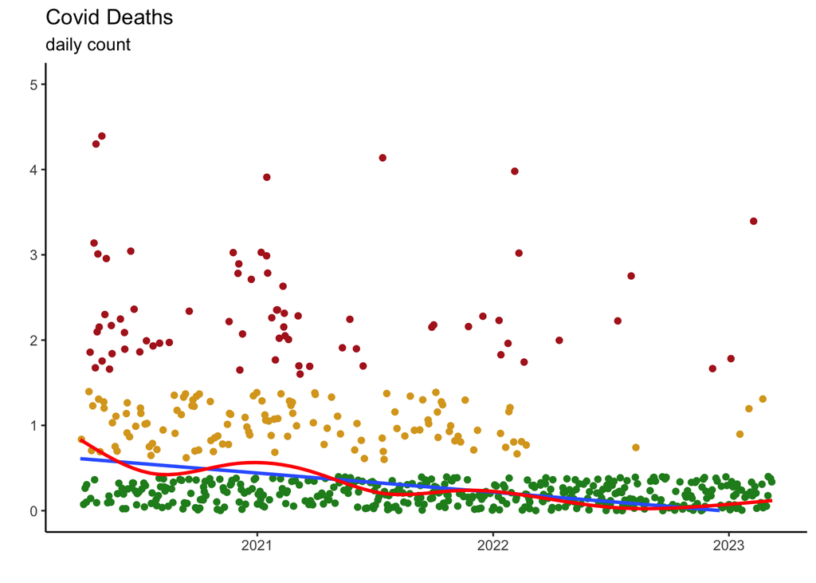

```r
# data is cleaned in cloud
jhu_covid19_durham_sinceApril %>%
  arrange(date) %>%
  mutate(daily_count = deaths - lag(deaths)) %>%
  filter(daily_count > -1) %>%
  mutate(scare = case_when(
    daily_count >= 2 ~ "high",
    daily_count == 1 ~ "medium",
    daily_count == 0 ~ "low"
  )) %>%
# piped into ggplot at the local level
  ggplot(aes(date, daily_count, "low", "medium")) +
  geom_jitter(aes(color = fct_relevel(scare, "low", "medium"))) +
  geom_smooth(method = lm, se = FALSE) +
  geom_smooth(color = "red", se = FALSE) +
  scale_color_manual(values = c("forestgreen", "goldenrod", "firebrick")) +
  ylim(0, 5) +
  guides(color = FALSE) +
  labs(title = "Covid Deaths", subtitle = "daily count",
       y = "", x = "") +
  theme_classic()
```

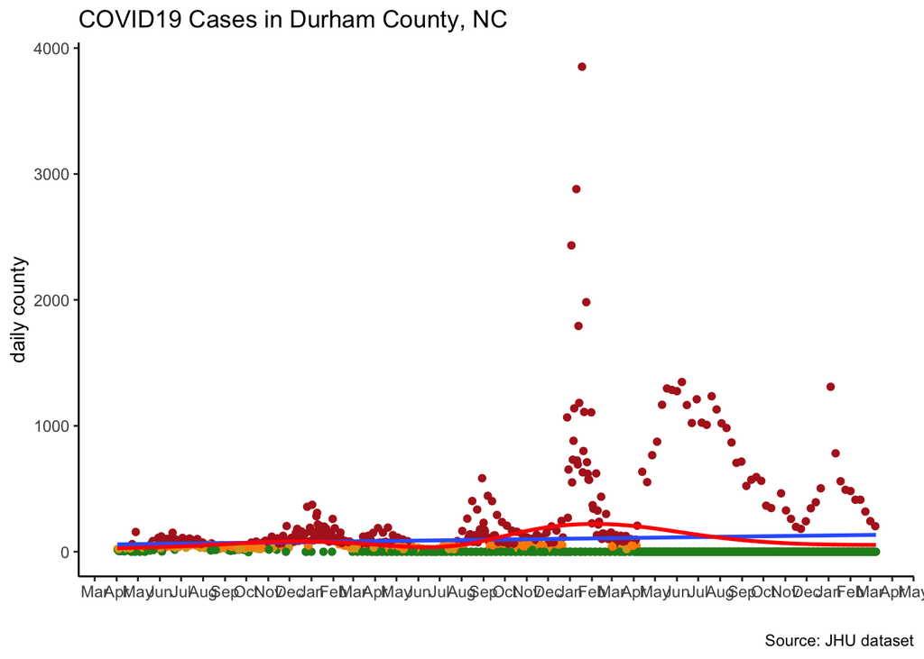

```r
jhu_covid19_durham_sinceApril %>%
  arrange(date) %>%
  mutate(daily_count = confirmed - lag(confirmed)) %>%
  mutate(scare = case_when(
    daily_count > 59 ~ "extreme",
    daily_count <= 59 & daily_count > 36  ~ "high",
    daily_count <= 36 & daily_count > 19 ~ "medium",
    daily_count <= 19 ~ "low"
  )) %>%
  ggplot(aes(date, daily_count, "low", "medium")) +
  geom_point(aes(color = fct_relevel(scare, "low", "medium", "high", "extreme"))) +
  geom_smooth(method = lm, se = FALSE) +
  geom_smooth(color = "red", se = FALSE) +
  scale_color_manual(values = c("forestgreen", "goldenrod", "darkorange", "firebrick")) +
  scale_x_date(breaks = "1 month", date_labels = "%b") +
  guides(color = FALSE) +
  labs(title = "COVID19 Cases in Durham County, NC",
       x = "", y = "daily county",
       caption = "Source: JHU dataset") +
  theme_classic()
```

```r
jhu_covid19_DBP_nc_counties %>%
  select(admin2, fips, province_state, confirmed, deaths) %>%
  rename(county = admin2, state = province_state, cases = confirmed) %>%
  arrange(-deaths)
```

| county | fips | state | cases | deaths |
| --- | --- | --- | --- | --- |
| Mecklenburg | 37119 | North Carolina | 11170 | 150 |
| Guilford | 37081 | North Carolina | 2812 | 114 |
| Durham | 37063 | North Carolina | 3679 | 63 |
| Henderson | 37089 | North Carolina | 610 | 50 |
| Wake | 37183 | North Carolina | 5178 | 47 |
| Chatham | 37037 | North Carolina | 950 | 43 |
| Rowan | 37159 | North Carolina | 1205 | 42 |
| Cumberland | 37051 | North Carolina | 1180 | 41 |
| Orange | 37135 | North Carolina | 669 | 41 |
| Buncombe | 37021 | North Carolina | 591 | 40 |

[output cut: 91 more lines]

## SQL – MORE

Here we can use the connection created at the top to run an SQL query in an RMarkdown code chunk

```sql
# this code chunk is saved as special_df

SELECT `province_state`, `country_region`, `date`,
       `latitude`, `longitude`, `confirmed`, `deaths`,
       `recovered`, `active`, `fips`, `admin2`, `combined_key`
FROM `summary`
WHERE ((`province_state` = 'North Carolina') AND (`date` = '2020-06-30'))
```

Above code chunk created the tibble `special_df` as identified in output.var

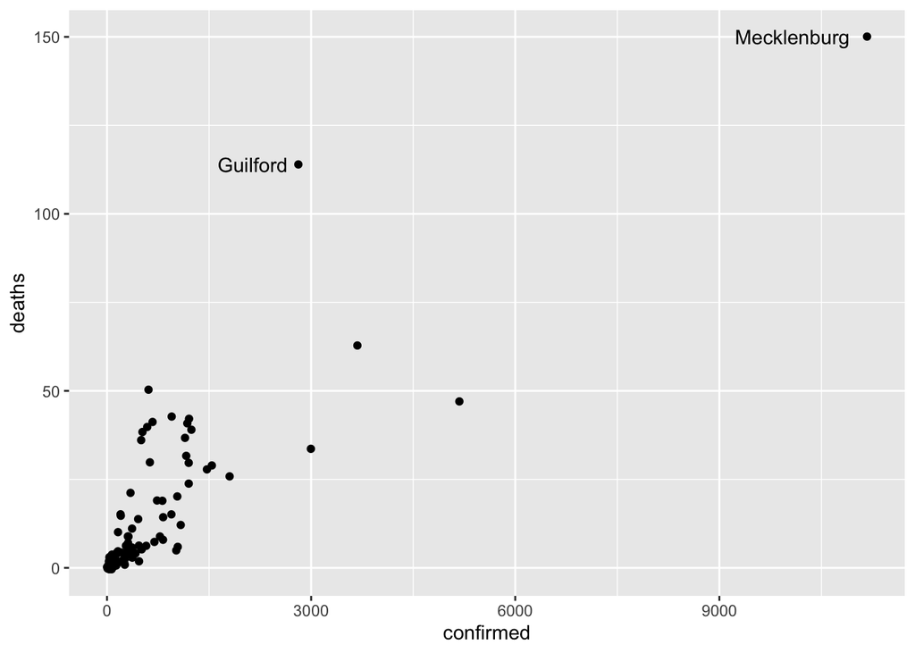

```r
special_df %>%
  ggplot(aes(confirmed, deaths)) +
  geom_jitter() +
  geom_text(data = . %>% filter(deaths > 100),
            aes(confirmed, deaths, label = admin2, hjust = 1.15))
```

## Example 2a: DBplyr and Austin Bikeshare trips

Make the connection to the `bigquery-public-data.austin_bikeshare` database.

```r
con2_bq_bikes <- dbConnect(
  bigrquery::bigquery(),
  project = "bigquery-public-data",
  dataset = "austin_bikeshare",
  billing = "fleet-furnace-316922"
)
con2_bq_bikes
```

```
## <BigQueryConnection>
##   Dataset: bigquery-public-data.austin_bikeshare
##   Billing: fleet-furnace-316922
```

Set the query pointer to `bigquery-public-data.austin_bikeshare.bikeshare_trips` table.

```r
bikeshare_trips <- tbl(con2_bq_bikes, "bikeshare_trips")
```

```r
austin_bikeshare_all <- bikeshare_trips %>%
  mutate(trip_id = as.double(trip_id)) %>%
  collect()
```

```r
austin_bikeshare_all
```

| trip_id | subscriber_type | bike_id | bike_type | start_time | start_station_id | start_station_name | end_station_id | end_station_name | duration_minutes |
| --- | --- | --- | --- | --- | --- | --- | --- | --- | --- |
| 7164831 | 24 Hour Walk Up Pass | 127 | classic | 2015-10-10 19:32:38 | 2574 | Zilker Park | NA | Stolen | 3632 |
| 7486759 | 24 Hour Walk Up Pass | 439 | classic | 2015-11-01 02:02:28 | 2496 | 8th/Congress | NA | Stolen | 6609 |
| 28430280 | Local31 | 19265 | electric | 2022-11-07 21:11:15 | 7189 | 28th/Rio | NA | 28th/Rio | 20 |
| 26978346 | Student Membership | 2034 | classic | 2022-06-21 16:27:28 | 7189 | 28th/Rio | 7189 | 28th/Rio | 15 |
| 27061704 | Local31 | 19165 | electric | 2022-06-30 18:46:43 | 7189 | 28th/Rio | 7189 | 28th/Rio | 68 |
| 26943859 | Explorer | 19552 | electric | 2022-06-17 22:33:56 | 7189 | 28th/Rio | 7189 | 28th/Rio | 66 |
| 26968398 | Local31 | 16828 | electric | 2022-06-20 13:50:27 | 7189 | 28th/Rio | 7189 | 28th/Rio | 51 |
| 26884432 | Local31 | 19869 | electric | 2022-06-10 21:55:10 | 7189 | 28th/Rio | 7189 | 28th/Rio | 22 |
| 26822085 | Student Membership | 21514 | electric | 2022-06-03 06:17:17 | 7189 | 28th/Rio | 7189 | 28th/Rio | 17 |
| 27044972 | Student Membership | 16845 | electric | 2022-06-28 19:53:46 | 7189 | 28th/Rio | 7189 | 28th/Rio | 50 |

[output cut: 9990 more lines]

```r
glimpse(austin_bikeshare_all)
```

```
## Rows: 1,975,266
## Columns: 10
## $ trip_id            <dbl> 7164831, 7486759, 28430280, 26978346, 27061704, 269…
## $ subscriber_type    <chr> "24 Hour Walk Up Pass", "24 Hour Walk Up Pass", "Lo…
## $ bike_id            <chr> "127", "439", "19265", "2034", "19165", "19552", "1…
## $ bike_type          <chr> "classic", "classic", "electric", "classic", "elect…
## $ start_time         <dttm> 2015-10-10 19:32:38, 2015-11-01 02:02:28, 2022-11-…
## $ start_station_id   <int> 2574, 2496, 7189, 7189, 7189, 7189, 7189, 7189, 718…
## $ start_station_name <chr> "Zilker Park", "8th/Congress", "28th/Rio", "28th/Ri…
## $ end_station_id     <chr> NA, NA, NA, "7189", "7189", "7189", "7189", "7189",…
## $ end_station_name   <chr> "Stolen", "Stolen", "28th/Rio", "28th/Rio", "28th/R…
## $ duration_minutes   <int> 3632, 6609, 20, 15, 68, 66, 51, 22, 17, 50, 16, 60,…
```

### Visualize

[How far is too far to bike to work?](https://mobilitylab.org/2017/02/27/how-far-bike-work/)

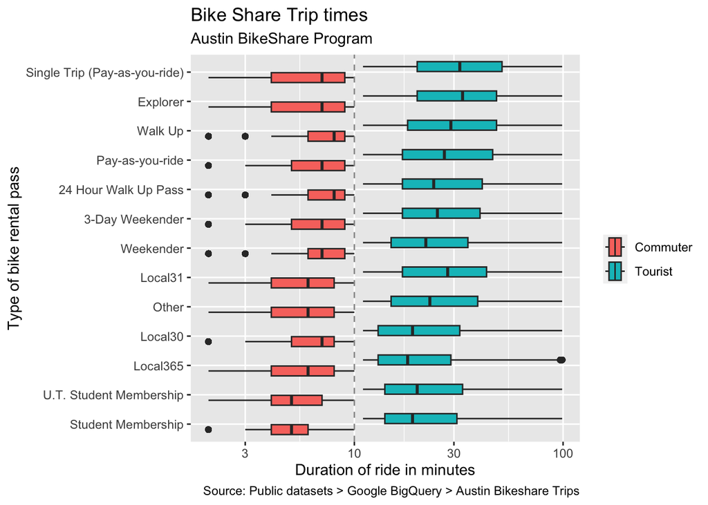

```r
austin_bikeshare_all %>%
  drop_na(subscriber_type) %>%
  filter(duration_minutes < 100) %>%
  mutate(travel_type = case_when(
    duration_minutes <= 10 ~ "Commuter",
    duration_minutes >  10 ~ "Tourist"
  )) %>%
  ggplot(aes(duration_minutes, fct_reorder(fct_lump(subscriber_type, prop = 0.01), duration_minutes))) +
  geom_boxplot(aes(fill = travel_type)) +
  geom_vline(xintercept = 10, linetype = "dashed", color = "grey60") +
  scale_x_log10() +
  labs(title = "Bike Share Trip times",
       subtitle = "Austin BikeShare Program",
       y = "Type of bike rental pass",
       x = "Duration of ride in minutes",
       caption = "Source: Public datasets > Google BigQuery > Austin Bikeshare Trips",
       fill = "")
```

```r
summary(austin_bikeshare_all)
```

```
##     trip_id         subscriber_type      bike_id           bike_type
##  Min.   : 1954839   Length:1975266     Length:1975266     Length:1975266
##  1st Qu.:12476112   Class :character   Class :character   Class :character
##  Median :18389413   Mode  :character   Mode  :character   Mode  :character
##  Mean   :17984246
##  3rd Qu.:25532763
##  Max.   :30074287
##
##    start_time                     start_station_id start_station_name
##  Min.   :2013-12-12 16:48:46.00   Min.   :1001     Length:1975266
##  1st Qu.:2016-10-20 14:28:29.75   1st Qu.:2547     Class :character
##  Median :2018-08-29 14:25:37.50   Median :2575     Mode  :character
##  Mean   :2019-01-29 00:26:20.29   Mean   :3163
##  3rd Qu.:2021-10-27 19:42:21.25   3rd Qu.:3794
##  Max.   :2023-06-30 23:47:17.00   Max.   :7341
##                                   NA's   :4447
##  end_station_id     end_station_name   duration_minutes
##  Length:1975266     Length:1975266     Min.   :    2.00
##  Class :character   Class :character   1st Qu.:    6.00
##  Mode  :character   Mode  :character   Median :   12.00
##                                        Mean   :   29.97
##                                        3rd Qu.:   28.00
##                                        Max.   :34238.00
##
```

## Example 2b: Austin BikeShare

List the top 5 percent of locations (stations) where bike-share trips begin and end.

Then, use `left_join()` to affect a database SQL join or table merge.

```r
left_tbl <- bikeshare_trips %>%
  count(start_station_name) %>%
  slice_max(order_by = n, prop = .05)
left_tbl
```

| start_station_name | n |
| --- | --- |
| 21st/Speedway @ PCL | 72127 |
| 21st & Speedway @PCL | 71145 |
| Dean Keeton/Speedway | 47765 |
| Zilker Park | 46722 |
| Riverside/South Lamar | 32112 |
| 21st/Guadalupe | 31865 |
| 26th/Nueces | 31240 |
| Rainey/Cummings | 30835 |
| Guadalupe/West Mall @ University Co-op | 29990 |
| Dean Keeton/Whitis | 28322 |

```r
right_tbl <- bikeshare_trips %>%
  count(end_station_name) %>%
  slice_max(order_by = n, prop = .05)
right_tbl
```

| end_station_name | n |
| --- | --- |
| 21st/Speedway @ PCL | 73330 |
| 21st & Speedway @PCL | 73312 |
| Dean Keeton/Speedway | 51873 |
| Zilker Park | 50774 |
| 21st/Guadalupe | 31708 |
| Riverside/South Lamar | 31544 |
| Dean Keeton & Speedway | 30131 |
| Rainey/Cummings | 29861 |
| 2nd/Lavaca @ City Hall | 29565 |
| 26th/Nueces | 29424 |

```r
left_join(left_tbl, right_tbl, by = c("start_station_name" = "end_station_name")) # %>% show_query()
```

| start_station_name | n_x | n_y |
| --- | --- | --- |
| 21st/Speedway @ PCL | 72127 | 73330 |
| 21st & Speedway @PCL | 71145 | 73312 |
| Dean Keeton/Speedway | 47765 | 51873 |
| Zilker Park | 46722 | 50774 |
| Riverside/South Lamar | 32112 | 31544 |
| 21st/Guadalupe | 31865 | 31708 |
| 26th/Nueces | 31240 | 29424 |
| Rainey/Cummings | 30835 | 29861 |
| Guadalupe/West Mall @ University Co-op | 29990 | NA |
| Dean Keeton/Whitis | 28322 | NA |

## Example 3: NYC tree census

Inspired by [Edgar Ruiz’s dbplyr presentation](https://rstudio.com/resources/rstudioconf-2019/databases-using-r-the-latest/)

[DBplot](https://db.rstudio.com/dbplot/) leverages dplyr to process the calculations of a plot inside a database.

```r
con_ny_trees <- dbConnect(
  bigrquery::bigquery(),
  project = "bigquery-public-data",
  dataset = "new_york_trees",
  billing = "fleet-furnace-316922"
)
con_ny_trees
```

```
## <BigQueryConnection>
##   Dataset: bigquery-public-data.new_york_trees
##   Billing: fleet-furnace-316922
```

```r
nytrees <- tbl(con_ny_trees, "tree_census_2015")
```

### Visualize

```r
library(dbplot)
library(leaflet)
```

```r
glimpse(nytrees)
```

```
## Rows: ??
## Columns: 41
## Database: BigQueryConnection
## $ tree_id    <int> 80548, 449489, 449293, 449153, 449148, 68192, 68347, 68393,…
## $ block_id   <int> 502982, 503216, 503196, 503188, 503152, 503778, 503349, 503…
## $ created_at <date> 2015-07-20, 2015-11-12, 2015-11-12, 2015-11-12, 2015-11-12…
## $ tree_dbh   <int> 0, 0, 0, 0, 0, 0, 0, 0, 0, 0, 0, 0, 0, 0, 0, 0, 0, 0, 0, 0,…
## $ stump_diam <int> 16, 4, 5, 10, 5, 3, 25, 2, 4, 3, 5, 8, 3, 4, 7, 6, 15, 12, …
## $ curb_loc   <chr> "OnCurb", "OnCurb", "OnCurb", "OnCurb", "OnCurb", "OnCurb",…
## $ status     <chr> "Stump", "Stump", "Stump", "Stump", "Stump", "Stump", "Stum…
## $ health     <chr> NA, NA, NA, NA, NA, NA, NA, NA, NA, NA, NA, NA, NA, NA, NA,…
## $ spc_latin  <chr> NA, NA, NA, NA, NA, NA, NA, NA, NA, NA, NA, NA, NA, NA, NA,…
## $ spc_common <chr> NA, NA, NA, NA, NA, NA, NA, NA, NA, NA, NA, NA, NA, NA, NA,…
## $ steward    <chr> NA, NA, NA, NA, NA, NA, NA, NA, NA, NA, NA, NA, NA, NA, NA,…
## $ guards     <chr> NA, NA, NA, NA, NA, NA, NA, NA, NA, NA, NA, NA, NA, NA, NA,…
```

[output cut: 29 more lines]

```r
nytrees %>%
  count(curb_loc)
```

| curb_loc | n |
| --- | --- |
| OnCurb | 656896 |
| OffsetFromCurb | 26892 |

#### dbplot_raster()

Above, we **subset the data at the database** to *good and healthy trees*, *offset from the curb*. Now use the `dbpot_raster()` function to **plot in R**

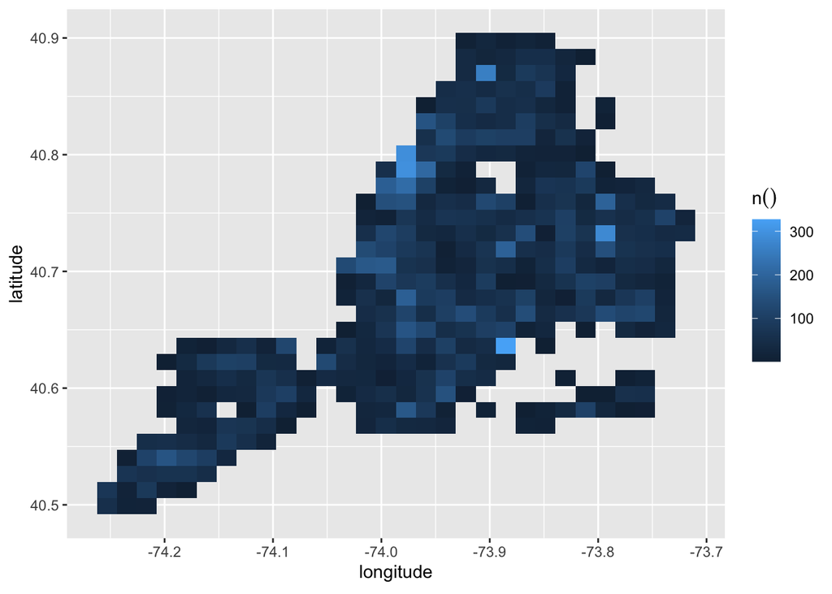

```r
locations <- nytrees %>%
  filter(curb_loc == "OffsetFromCurb") %>%
  filter(health == "Good") %>%
  dbplot_raster(longitude, latitude, resolution = 30)
  # db_compute_raster(longitude, latitude, resolution = 30)
locations
```

#### db_compute_raster()

```r
nytrees %>%
  filter(curb_loc == "OffsetFromCurb") %>%
  filter(health == "Good") %>%
  count()
```

| n |
| --- |
| 20877 |

```r
locations_tbl <- nytrees %>%
  filter(curb_loc == "OffsetFromCurb") %>%
  filter(health == "Good") %>%
  db_compute_raster(longitude, latitude, resolution = 30)
locations_tbl
```

| longitude | latitude | n() |
| --- | --- | --- |
| -73.92213 | 40.88357 | 37 |
| -73.84855 | 40.88357 | 51 |
| -73.83016 | 40.77366 | 67 |
| -73.79337 | 40.73244 | 281 |
| -73.88534 | 40.73244 | 60 |
| -73.84855 | 40.71870 | 46 |
| -73.73818 | 40.65000 | 27 |
| -73.94053 | 40.67748 | 98 |
| -74.03251 | 40.63626 | 60 |
| -74.05090 | 40.62252 | 129 |

[output cut: 354 more lines]

#### Tidy evaluation functions

Tidy eval function [by Ruiz (timestamp 13:47)](https://rstudio.com/resources/rstudioconf-2019/databases-using-r-the-latest/)

```r
size <- function(df, field) {
  field <- enquo(field)
  df %>%
    arrange(!! field) %>%
    mutate(diff = !! field - lag(!! field)) %>%
    filter(diff > 0) %>%
    summarise(min(diff)) %>%
    pull()
}
```

```r
lon_size <- locations_tbl %>%
  size(longitude)

lon_size
```

```
## [1] 0.01839551
```

```r
lat_size <- locations_tbl %>%
  size(latitude)

lat_size
```

```
## [1] 0.01373925
```

```r
sq <- locations_tbl %>%
  mutate(lon1 = longitude,
         lon2 = longitude + lon_size,
         lat1 = latitude,
         lat2 = latitude + lat_size,
         of_max = `n()` / max(`n()`)
  )
```

#### Leaflet map

```r
leaflet() %>%
  addTiles() %>%
  addRectangles(
    sq$lon1, sq$lat1, sq$lon2, sq$lat2
  )
```

[interactive chart not shown]

```r
fancy <- leaflet() %>%
  addTiles() %>%
  addProviderTiles(providers$CartoDB.Positron) %>%
  addRectangles(
    sq$lon1, sq$lat1, sq$lon2, sq$lat2,
    fillOpacity = sq$of_max,
    fillColor = "forestgreen",
    stroke = FALSE,
    popup = glue::glue('Trees {sq$`n()`}')
  )

fancy
```

[interactive chart not shown]

```r
library(mapview)
mapshot(fancy, file = "images/tree_cover.png")
```

```
## PhantomJS not found. You can install it with webshot::install_phantomjs(). If it is installed, please make sure the phantomjs executable can be found via the PATH variable.
```

## Resources

- [Databases using R](https://db.rstudio.com/)
- [library(DBI)](https://dbi.r-dbi.org/reference/)
- [library(bigrquery)](https://bigrquery.r-dbi.org/)
- [library(dbplyr)](https://dbplyr.tidyverse.org/)
- [RStudio Conf 2019, 15 min. Recording](https://rstudio.com/resources/rstudioconf-2019/databases-using-r-the-latest/)